# Housing_Price_Prediction

```python
# Library to suppress warnings or deprecation notes
import warnings
warnings.filterwarnings('ignore')

# Libraries to help with reading and manipulating data
import numpy as np
import pandas as pd

# Libraries to help with data visualization
import matplotlib.pyplot as plt
%matplotlib inline
import seaborn as sns

# Libraries to split data, impute missing values
from sklearn.model_selection import train_test_split
from sklearn.impute import SimpleImputer
from sklearn.compose import ColumnTransformer
from sklearn.preprocessing import OneHotEncoder, StandardScaler
from sklearn.pipeline import Pipeline


#Libraries for Linear Regression models,tune model, get different metric scores
from sklearn import metrics
from sklearn.metrics import confusion_matrix, classification_report, accuracy_score, precision_score, recall_score, f1_score, roc_auc_score
from sklearn.metrics import mean_squared_error, mean_absolute_error, r2_score
from sklearn.linear_model import LinearRegression, Ridge, Lasso
from sklearn.model_selection import cross_val_score, GridSearchCV, RandomizedSearchCV
from sklearn.ensemble import BaggingRegressor,RandomForestRegressor, GradientBoostingRegressor, AdaBoostRegressor, StackingRegressor
from xgboost import XGBRegressor
```

## Loading Datasets

```python
# to get data from kaggle site
train_df = pd.read_csv("/kaggle/input/house-prices-advanced-regression-techniques/train.csv")
test_df = pd.read_csv("/kaggle/input/house-prices-advanced-regression-techniques/test.csv")
```

```python
from google.colab import files
import io
import pandas as pd

# Upload the train data file
print("Please upload the **training** data file:")
uploaded_train = files.upload()
filename_train = list(uploaded_train.keys())[0]
train = pd.read_csv(io.BytesIO(uploaded_train[filename_train]))
print(f"✅ Training file '{filename_train}' uploaded and read successfully!")

# Upload the test data file
print("\nPlease upload the **testing** data file:")
uploaded_test = files.upload()
filename_test = list(uploaded_test.keys())[0]
test = pd.read_csv(io.BytesIO(uploaded_test[filename_test]))
print(f"✅ Testing file '{filename_test}' uploaded and read successfully!")
```

```
Please upload the **training** data file:
```

Upload widget is only available when the cell has been executed in the current browser session. Please rerun this cell to enable.

```
Saving train_data.csv to train_data (1).csv
✅ Training file 'train_data (1).csv' uploaded and read successfully!

Please upload the **testing** data file:
```

Upload widget is only available when the cell has been executed in the current browser session. Please rerun this cell to enable.

```
Saving test_data.csv to test_data (1).csv
✅ Testing file 'test_data (1).csv' uploaded and read successfully!
```

## Data Analysis

```python
print(f"The Training data has {train.shape[0]} rows and {train.shape[1]} columns.")
print("**"*50)
print(f"The Test data has {test.shape[0]} rows and {test.shape[1]} columns.")
print("**"*50)
train.head()
```

```
The Training data has 1460 rows and 81 columns.
The Test data has 1459 rows and 80 columns.
```

|  | Id | MSSubClass | MSZoning | LotFrontage | LotArea | Street | Alley | LotShape | LandContour | Utilities | ... | PoolArea | PoolQC | Fence | MiscFeature | MiscVal | MoSold | YrSold | SaleType | SaleCondition | SalePrice |
| --- | --- | --- | --- | --- | --- | --- | --- | --- | --- | --- | --- | --- | --- | --- | --- | --- | --- | --- | --- | --- | --- |
| 0 | 1 | 60 | RL | 65.0 | 8450 | Pave | NaN | Reg | Lvl | AllPub | ... | 0 | NaN | NaN | NaN | 0 | 2 | 2008 | WD | Normal | 208500 |
| 1 | 2 | 20 | RL | 80.0 | 9600 | Pave | NaN | Reg | Lvl | AllPub | ... | 0 | NaN | NaN | NaN | 0 | 5 | 2007 | WD | Normal | 181500 |
| 2 | 3 | 60 | RL | 68.0 | 11250 | Pave | NaN | IR1 | Lvl | AllPub | ... | 0 | NaN | NaN | NaN | 0 | 9 | 2008 | WD | Normal | 223500 |
| 3 | 4 | 70 | RL | 60.0 | 9550 | Pave | NaN | IR1 | Lvl | AllPub | ... | 0 | NaN | NaN | NaN | 0 | 2 | 2006 | WD | Abnorml | 140000 |
| 4 | 5 | 60 | RL | 84.0 | 14260 | Pave | NaN | IR1 | Lvl | AllPub | ... | 0 | NaN | NaN | NaN | 0 | 12 | 2008 | WD | Normal | 250000 |

5 rows × 81 columns

```python
train.info()
print("**"*50)
```

```
<class 'pandas.core.frame.DataFrame'>
RangeIndex: 1460 entries, 0 to 1459
Data columns (total 81 columns):
 #   Column         Non-Null Count  Dtype
---  ------         --------------  -----
 0   Id             1460 non-null   int64
 1   MSSubClass     1460 non-null   int64
 2   MSZoning       1460 non-null   object
 3   LotFrontage    1201 non-null   float64
 4   LotArea        1460 non-null   int64
 5   Street         1460 non-null   object
 6   Alley          91 non-null     object
 7   LotShape       1460 non-null   object
 8   LandContour    1460 non-null   object
 9   Utilities      1460 non-null   object
```

[output cut: 73 more lines]

## Exploratory Data Analysis

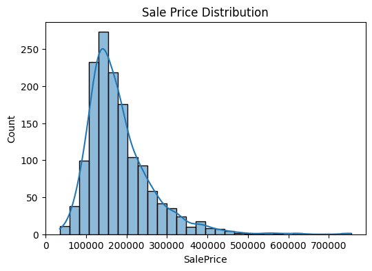

```python
plt.figure(figsize=(6,4))
sns.histplot(train["SalePrice"], bins=30, kde=True)
plt.title("Sale Price Distribution")
plt.show();
```

The distribution of SalePrice is right-skewed or positively skewed indicating that most of the data points are concentrated on the left side of the plot (lower prices), while a smaller number of higher prices trail off to the right.

**Correlation Check**

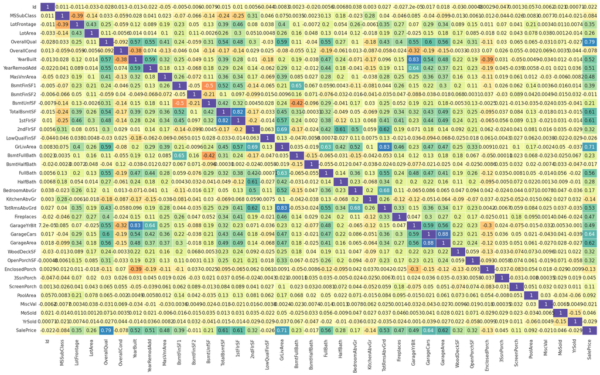

```python
# Check for correlations
sns.set(rc={'figure.figsize':(25,15)})
sns.heatmap(train.corr(numeric_only=True),
            annot=True,
            linewidths=.5,
            center=0,
            cbar=False,
            cmap="Spectral")
plt.show()
```

- `OverallQual`, `GrLivArea`, `GarageCars`, `GarageArea`, `TotalBsmtSF`, `1stFlrSF` has a high positive correlation with sales price

**Distribution of SalePrice across Overall Quality**

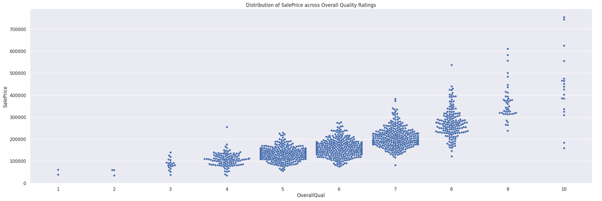

```python
sns.set(rc={'figure.figsize':(10,5)})
sns.catplot(x=train["OverallQual"], y=train["SalePrice"], kind="swarm"
, height=7, aspect=3).set(title="Distribution of SalePrice across Overall Quality Ratings")
plt.show();
```

- The swarm plot effectively shows the strong positive relationship between sale prices and overall quality, making it clear that homes with higher quality ratings tend to have higher sale prices.
- The plot also reveals that the variance in SalePrice increases with higher OverallQual ratings, as the vertical spread of the points becomes wider for quality ratings of 7 and above. This indicates a wider range of prices for homes with a better overall quality.

## Featured Engineering

**Check for missing values**

```python
# List of columns with missing data in train set
missing_cols = train.isna().sum()
missing_cols = missing_cols[missing_cols > 0] # selects those with count > 0
missing_percent = (train.isnull().sum() / len(train)) * 100

# put it into dataframe
missing_data = pd.DataFrame({
    'Missing Values': missing_cols,
    'Percentage': missing_percent
})
missing_data = missing_data[missing_data['Missing Values'] > 0]

print(missing_data.sort_values(by='Missing Values', ascending=False).head(20))
print(f'There are', missing_cols.shape[0], 'columns with missing data')
```

```
              Missing Values  Percentage
PoolQC                1453.0   99.520548
MiscFeature           1406.0   96.301370
Alley                 1369.0   93.767123
Fence                 1179.0   80.753425
MasVnrType             872.0   59.726027
FireplaceQu            690.0   47.260274
LotFrontage            259.0   17.739726
GarageYrBlt             81.0    5.547945
GarageType              81.0    5.547945
GarageFinish            81.0    5.547945
GarageCond              81.0    5.547945
GarageQual              81.0    5.547945
BsmtExposure            38.0    2.602740
BsmtFinType2            38.0    2.602740
BsmtCond                37.0    2.534247
BsmtFinType1            37.0    2.534247
BsmtQual                37.0    2.534247
MasVnrArea               8.0    0.547945
Electrical               1.0    0.068493
There are 19 columns with missing data
```

### Treat missing values in both train and test data.

- Create a function to treat missing values

```python
def treat_missing_data(df, num_medians=None, cat_modes=None, is_train=True):
    """
    Clean missing values for both train and test dataframes.

    Parameters
    ----------
    df : DataFrame
        Input dataframe to clean.
    num_medians : dict, optional
        Precomputed medians for numeric columns (from train).
    cat_modes : dict, optional
        Precomputed modes for categorical columns (from train).
    is_train : bool, default=True
        Whether this is training data (compute stats) or test data (apply stats).

    Returns
    -------
    df : DataFrame
        Cleaned dataframe with no missing values.
    num_medians : dict
        Dictionary of computed medians for numeric columns.
    cat_modes : dict
        Dictionary of computed modes for categorical columns.
    """

    df = df.copy()

    # Separate column types
    cat_cols = df.select_dtypes(include=["object", "category"]).columns
    num_cols = df.select_dtypes(include=["number"]).columns

    # =============================
    # TRAIN: compute statistics
    # =============================
    if is_train:
        num_medians = {col: df[col].median() for col in num_cols}
        cat_modes = {col: df[col].mode(dropna=True)[0] if not df[col].mode(dropna=True).empty else "None"
                     for col in cat_cols}

    # =============================
    # APPLY: impute missing values
    # =============================

    # Fill numeric columns with train medians
    for col in num_cols:
        fill_value = num_medians.get(col, 0)  # fallback 0 if unseen column
        df[col] = df[col].fillna(fill_value)

    # Fill categorical columns with train modes
    for col in cat_cols:
        fill_value = cat_modes.get(col, "None")  # fallback "None"
        df[col] = df[col].fillna(fill_value)

        # Handle unseen categories in test → replace with "Other"
        if not is_train:
            known_categories = set(df[col].unique()).union({fill_value})
            df[col] = df[col].where(df[col].isin(known_categories), "Other")

    return df, num_medians, cat_modes
```

```python
# Train: learn medians & modes
train_clean, num_medians, cat_modes = treat_missing_data(train, is_train=True)

# Test: apply same medians & modes
test_clean, _, _ = treat_missing_data(test,
                                      num_medians=num_medians,
                                      cat_modes=cat_modes,
                                      is_train=False)

# Confirm no missing values
print(train_clean.isna().sum().sum())  # should be 0
print(test_clean.isna().sum().sum())   # should be 0
```

```
0
0
```

There are no more missing values in the datasets.

## Data Preprocessing

```python
# split train data
y = train_clean["SalePrice"]
X = train_clean.drop(columns=["SalePrice"])
```

```python
# Separate features
cat_cols = X.select_dtypes(include=["object", "category"]).columns
num_cols = X.select_dtypes(include=["number"]).columns

# Preprocessor for Ridge/Lasso (scaling + encoding)
rl_preprocessor = ColumnTransformer(
    transformers=[
        ("num", StandardScaler(), num_cols),       # scaling numeric features
        ("cat", OneHotEncoder(handle_unknown="ignore"), cat_cols)  # one-hot for categorical
    ]
)

# Preprocessor for Tree-based models (only encoding, no scaling)
tree_preprocessor = ColumnTransformer(
    transformers=[
        ("num", "passthrough", num_cols),  # Leave numeric features as-is, no scaling
        ("cat", OneHotEncoder(handle_unknown="ignore"), cat_cols)  # One-hot encode categoricals
    ]
)
```

```python
# split X into training & validation
X_train, X_valid, y_train, y_valid = train_test_split(
    X, y, test_size=0.25, random_state=42
)
```

### Linear Regression Pipeline (using Ridge/Lasso Regression)

```python
# Ridge pipeline
ridge_pipeline = Pipeline(steps=[
    ("preprocessor", rl_preprocessor),  # Apply scaling + encoding
    ("model", Ridge(alpha=1.0))             # Regularized linear regression
])

# Lasso pipeline
lasso_pipeline = Pipeline(steps=[
    ("preprocessor", rl_preprocessor),  # Same preprocessing
    ("model", Lasso(alpha=0.001))           # Lasso regression
])
```

### Tree-Based Pipeline (Random Forest, Gradient Boosting and XGB)

```python
# Random Forest pipeline
rf_pipeline = Pipeline(steps=[
    ("preprocessor", tree_preprocessor),  # Encode categoricals, pass numeric raw
    ("model", RandomForestRegressor(n_estimators=200, random_state=42))
])

# Gradient Boosting pipeline
gb_pipeline = Pipeline(steps=[
    ("preprocessor", tree_preprocessor),  # Same preprocessing
    ("model", GradientBoostingRegressor(n_estimators=300, learning_rate=0.05, random_state=42))
])

# XGB pipeline
xgb_pipeline = Pipeline(steps=[
    ("preprocessor", tree_preprocessor),  # Same preprocessing
    ("model", XGBRegressor(n_estimators=200, learning_rate=0.05, max_depth=4, random_state=42))
])
```

## Building Model

```python
# Fit pipelines on training set
ridge_pipeline.fit(X_train, y_train)

# Evaluate on validation set
y_pred_valid = ridge_pipeline.predict(X_valid)

# Compute RMSE / R² / MAE
rmse = np.sqrt(mean_squared_error(y_valid, y_pred_valid))
r2 = r2_score(y_valid, y_pred_valid)
mae = mean_absolute_error(y_valid, y_pred_valid)  # to compute MAE

print(f"Validation RMSE: {rmse:.2f}, R²: {r2:.3f}, MAE: {mae:.3f}")
```

```
Validation RMSE: 28253.17, R²: 0.886, MAE: 18459.052
```

```python
def evaluate_model(pipeline, X_train, y_train, X_valid, y_valid, model_name="Model"):
    """
    Fit a pipeline on training data, predict on validation data,
    and compute RMSE, R², MAE, and Adj_R².

    Parameters:
    -----------
    pipeline : sklearn pipeline (already defined)
    X_train, y_train : training data
    X_valid, y_valid : validation data
    model_name : str, optional (for display purposes)

    Returns:
    --------
    dict : containing rmse, r2, mae, and adj_r2
    """
    # Fit model
    pipeline.fit(X_train, y_train)

    # Predict
    y_pred_valid = pipeline.predict(X_valid)

    # function to compute adjusted R-squared
    def adj_r2_score(predictors, targets, predictions):
        r2 = r2_score(targets, predictions)
        n = predictors.shape[0]
        k = predictors.shape[1]
        return 1 - ((1 - r2) * (n - 1) / (n - k - 1))


    # Metrics
    rmse = np.sqrt(mean_squared_error(y_valid, y_pred_valid))
    r2 = r2_score(y_valid, y_pred_valid)
    mae = mean_absolute_error(y_valid, y_pred_valid)
    adj_r2 = adj_r2_score(X_valid, y_valid, y_pred_valid)

    # Return metrics as a dictionary
    return {
        "Model": model_name,
        "RMSE": rmse,
        "MAE": mae,
        "R²": r2,
        "Adjusted R²": adj_r2
    }
```

```python
# Ridge
ridge_results = evaluate_model(ridge_pipeline, X_train, y_train, X_valid, y_valid, model_name="Ridge")
ridge_results
```

[output not shown]

```python
# Lasso
lasso_results = evaluate_model(lasso_pipeline, X_train, y_train, X_valid, y_valid, model_name="Lasso")
lasso_results
```

[output not shown]

```python
# Random Forest
rf_results = evaluate_model(rf_pipeline, X_train, y_train, X_valid, y_valid, model_name="Random Forest")
rf_results
```

[output not shown]

```python
# Gradient Boosting
gb_results = evaluate_model(gb_pipeline, X_train, y_train, X_valid, y_valid, model_name="Gradient Boosting")
gb_results
```

[output not shown]

```python
xgb_results = evaluate_model(xgb_pipeline, X_train, y_train, X_valid, y_valid, "XGBoost")
xgb_results
```

[output not shown]

## Model Comparison

```python
# training performance comparison

models_train_comp_df = pd.concat(
    [ridge_results.T, lasso_results.T, rf_results.T, gb_results.T,xgb_results.T],
    axis=1,
)

models_train_comp_df.columns = [
    "Ridge Model",
    "Lasso Model",
    "Random Forest Estimator",
    "Gradient Boost Estimator",
    "XGB"
]

print("Training performance comparison:")
models_train_comp_df
```

```
Training performance comparison:
```

[output not shown]

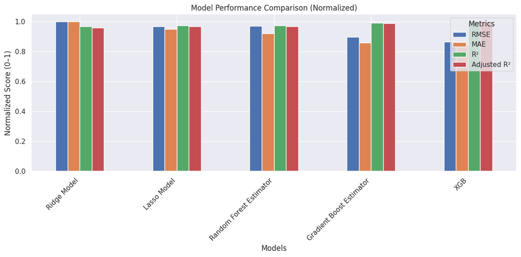

```python
# Normalize metrics between 0 and 1
metrics_df_norm = models_train_comp_df.astype(float).apply(lambda x: x / x.max(), axis=1)

# Transpose for plotting
metrics_df_norm_T = metrics_df_norm.T

# Plot
ax = metrics_df_norm_T.plot(kind="bar", figsize=(12,6))
plt.title("Model Performance Comparison (Normalized)")
plt.xlabel("Models")
plt.ylabel("Normalized Score (0–1)")
plt.xticks(rotation=45, ha='right')
plt.legend(title="Metrics")
plt.tight_layout()
plt.show()
```

Important Features

```python
# Getting the top 10 important features


# Get feature names after preprocessing for Ridge
ridge_feature_names = ridge_pipeline.named_steps["preprocessor"].get_feature_names_out()

# Get feature names after preprocessing for XGBoost
xgb_feature_names = xgb_pipeline.named_steps["preprocessor"].get_feature_names_out()


print("Ridge Model Coefficients:")
print(pd.DataFrame(ridge_pipeline.named_steps["model"].coef_, columns = ["Coef"], index = ridge_feature_names).sort_values(by = 'Coef', ascending = False).head(10))
print("\nXGBoost Model Feature Importances:")
print(pd.DataFrame(xgb_pipeline.named_steps["model"].feature_importances_, columns = ["Imp"], index = xgb_feature_names).sort_values(by = 'Imp', ascending = False).head(10))
```

```
Ridge Model Coefficients:
                                   Coef
cat__PoolQC_Ex             68240.625468
cat__RoofMatl_WdShngl      58839.696701
cat__Neighborhood_StoneBr  41845.321377
cat__GarageQual_Ex         38221.492480
cat__RoofMatl_CompShg      32639.773356
cat__Neighborhood_NoRidge  31890.763838
cat__RoofMatl_WdShake      29183.566328
cat__Exterior2nd_ImStucc   28804.848768
cat__Condition2_Norm       27268.589541
cat__Condition2_Artery     25856.446198

XGBoost Model Feature Importances:
                             Imp
num__OverallQual        0.247940
cat__GarageFinish_Unf   0.062412
num__GarageCars         0.062099
cat__RoofMatl_CompShg   0.045927
cat__BsmtQual_Ex        0.045793
cat__KitchenQual_Gd     0.043390
cat__ExterQual_TA       0.034484
num__GrLivArea          0.029840
num__FullBath           0.026298
cat__GarageType_Detchd  0.021262
```

- The best model is XGB with highest values for R² and Adj. R², and lowest values for RMSE and MAE.
- So retrain XGB model on full training set (X, y)
- Then we use the XGB to predict the SalePrice for the test data.

### Hyperparameter Tuning

Define tuning pipelines with your existing preprocessor

```python
#  Ridge
ridge_tune_pipeline = Pipeline([
    ("preprocessor", rl_preprocessor),  # your original preprocessing step
    ("regressor", Ridge())
])

# Lasso
lasso_tune_pipeline = Pipeline([
    ("preprocessor", rl_preprocessor),
    ("regressor", Lasso(max_iter=10000))  # safe for convergence
])

# Random Forest
rf_tune_pipeline = Pipeline([
    ("preprocessor", tree_preprocessor),
    ("regressor", RandomForestRegressor(random_state=42))
])

# Gradient Boosting pipeline
gb_tune_pipeline = Pipeline([
    ("preprocessor", tree_preprocessor),
    ("regressor", GradientBoostingRegressor(random_state=42))
])

# XGBoost
xgb_tune_pipeline = Pipeline([
    ("preprocessor", tree_preprocessor),
    ("regressor", XGBRegressor(random_state=42, verbosity=0))
])
```

Define parameter grids

```python
ridge_params = {
    "regressor__alpha": [0.01, 0.1, 1, 10, 100],
    "regressor__solver": ["auto", "svd", "lsqr"]
}

lasso_params = {
    "regressor__alpha": [0.0001, 0.001, 0.01, 0.1, 1, 10]
}

rf_params = {
    "regressor__n_estimators": [100, 300],
    "regressor__max_depth": [None, 6, 8, 10],
    "regressor__min_samples_split": [2, 5],
    "regressor__min_samples_leaf": [1, 2]
}

gb_params = {
    "regressor__n_estimators": [100, 300],
    "regressor__subsample":[0.8,0.9,1],
    "regressor__max_features":[0.8,0.9,1],
    "regressor__learning_rate": [0.01, 0.1],
    "regressor__max_depth": [3, 5]
}

xgb_params = {
    "regressor__n_estimators": [200, 500],
    "regressor__max_depth": [3, 5],
    "regressor__learning_rate": [0.01, 0.1],
    "regressor__subsample": [0.8, 1.0],
    "regressor__colsample_bytree": [0.8, 1.0]
}
```

Tunning Models

```python
# using GridSearchCV

def tune_model(pipeline, param_grid, X_train, y_train, model_name):
    grid = GridSearchCV(
        pipeline,
        param_grid,
        cv=3,
        scoring="neg_root_mean_squared_error",
        n_jobs=-1,
        verbose=2
    )
    grid.fit(X_train, y_train)
    print(f"Best {model_name} params:", grid.best_params_)
    print(f"Best {model_name} CV RMSE:", -grid.best_score_)
    return grid.best_estimator_

# Run tuning
best_ridge = tune_model(ridge_tune_pipeline, ridge_params, X_train, y_train, "Ridge")
best_lasso = tune_model(lasso_tune_pipeline, lasso_params, X_train, y_train, "Lasso")
best_rf   = tune_model(rf_tune_pipeline, rf_params, X_train, y_train, "Random Forest")
best_gb   = tune_model(gb_tune_pipeline, gb_params, X_train, y_train, "Gradient Boosting")
best_xgb  = tune_model(xgb_tune_pipeline, xgb_params, X_train, y_train, "XGBoost")
```

[output not shown]

Evaluating the tuned models

```python
lasso_grid_results = [evaluate_model(best_lasso, X_train, y_train, X_valid, y_valid, model_name="best_lasso")]
lasso_grid_results_df = pd.DataFrame(lasso_grid_results)
print(lasso_grid_results_df.to_string(index=False))
# print(lasso_random_results_df.to_string(index=False))
lasso_grid_results_df
```

```
     Model         RMSE          MAE       R²  Adjusted R²
best_lasso 26199.113069 16540.742424 0.902018     0.874418
```

|  | Model | RMSE | MAE | R² | Adjusted R² |
| --- | --- | --- | --- | --- | --- |
| 0 | best_lasso | 26199.113069 | 16540.742424 | 0.902018 | 0.874418 |

```python
# evaluate the model in a data frame

models_tuned = {
    "Ridge": best_ridge,
    "Lasso": best_lasso,
    "RandomForest": best_rf,
    "GradientBoost": best_gb,
    "XGBoost": best_xgb
}

results_list = []
for name, model in models_tuned.items():
    metrics = evaluate_model(model, X_train, y_train, X_valid, y_valid, model_name=name)
    results_list.append(metrics)

results_df = pd.DataFrame(results_list)
print(results_df.to_string(index=False))
```

```
        Model         RMSE          MAE       R²  Adjusted R²
        Ridge 29268.492734 18630.045118 0.877715     0.843268
        Lasso 26199.113069 16540.742424 0.902018     0.874418
 RandomForest 27534.235500 17070.607556 0.891777     0.861292
GradientBoost 24467.948930 15626.722484 0.914539     0.890466
      XGBoost 24085.501033 15129.782227 0.917190     0.893863
```

Hyperparameter Tuning with RandomizedSearchCV

```python
from sklearn.model_selection import RandomizedSearchCV

# ---- Ridge (small grid, keep GridSearch)
ridge_random = RandomizedSearchCV(
    ridge_tune_pipeline,
    ridge_params,
    cv=3,
    scoring="neg_root_mean_squared_error",
    n_jobs=-1,
    verbose=2,
    random_state=42  # for reproducibility
)

# ---- Lasso (Randomized Search)
lasso_random = RandomizedSearchCV(
    lasso_tune_pipeline,
    {"regressor__alpha": np.logspace(-4, 2, 100)},  # fine-grained alpha search
    n_iter=20,
    cv=3,
    scoring="neg_root_mean_squared_error",
    n_jobs=-1,
    random_state=42,
    verbose=2
)

# ---- Random Forest (Randomized Search)
rf_random = RandomizedSearchCV(
    rf_tune_pipeline,
    {
        "regressor__n_estimators": [100, 200, 300, 500],
        "regressor__max_depth": [None, 10, 20, 30],
        "regressor__min_samples_split": [2, 5, 10],
        "regressor__min_samples_leaf": [1, 2, 4]
    },
    n_iter=20,   # limits search space
    cv=3,
    scoring="neg_root_mean_squared_error",
    n_jobs=-1,
    random_state=42,
    verbose=2
)

# ---- GB (Randomized Search)
gb_random = RandomizedSearchCV(
    gb_tune_pipeline,
    {
        "regressor__n_estimators": [100, 200],
        "regressor__learning_rate": [0.01, 0.05, 0.1, 0.5],
        "regressor__max_depth": [3, 5, 7],
        "regressor__subsample": [0.6, 0.8, 1.0],
        "regressor__max_features":[0.5,0.7,1],
    }
)

# ---- XGBoost (Randomized Search)
xgb_random = RandomizedSearchCV(
    xgb_tune_pipeline,
    {
        "regressor__n_estimators": [200, 300, 500, 800],
        "regressor__max_depth": [3, 4, 5, 6],
        "regressor__learning_rate": [0.001, 0.01, 0.05, 0.1],
        "regressor__subsample": [0.7, 0.8, 1.0],
        "regressor__colsample_bytree": [0.7, 0.8, 1.0]
    },
    n_iter=25,
    cv=3,
    scoring="neg_root_mean_squared_error",
    n_jobs=-1,
    random_state=42,  # for reproducibility
    verbose=2
)
```

```python
ridge_random_results = [evaluate_model(ridge_random, X_train, y_train, X_valid, y_valid, model_name="ridge_random")]
ridge_random_results_df = pd.DataFrame(ridge_random_results)
ridge_random_df = ridge_random_results_df.drop(columns=[col for col in ridge_random_results_df.columns if col == "Model"])
ridge_random_df
```

```
Fitting 3 folds for each of 10 candidates, totalling 30 fits
```

|  | RMSE | MAE | R² | Adjusted R² |
| --- | --- | --- | --- | --- |
| 0 | 29268.492734 | 18630.045118 | 0.877715 | 0.843268 |

```python
lasso_random_results = [evaluate_model(lasso_random, X_train, y_train, X_valid, y_valid, model_name="lasso_random")]
lasso_random_results_df = pd.DataFrame(lasso_random_results)
lasso_random_results_df = lasso_random_results_df.drop(columns=[col for col in lasso_random_results_df.columns if col == "Model"])
lasso_random_results_df
```

```
Fitting 3 folds for each of 20 candidates, totalling 60 fits
```

|  | RMSE | MAE | R² | Adjusted R² |
| --- | --- | --- | --- | --- |
| 0 | 26000.905015 | 16233.86623 | 0.903495 | 0.876311 |

```python
rf_random_results = [evaluate_model(rf_random, X_train, y_train, X_valid, y_valid, model_name="rf_random")]
rf_random_results_df = pd.DataFrame(rf_random_results)
rf_random_results_df = rf_random_results_df.drop(columns=[col for col in rf_random_results_df.columns if col == "Model"])
rf_random_results_df
```

```
Fitting 3 folds for each of 20 candidates, totalling 60 fits
```

|  | RMSE | MAE | R² | Adjusted R² |
| --- | --- | --- | --- | --- |
| 0 | 27556.066606 | 17078.088255 | 0.891606 | 0.861072 |

```python
gb_random_results = [evaluate_model(gb_random, X_train, y_train, X_valid, y_valid, model_name="gb_random")]
gb_random_results_df= pd.DataFrame(gb_random_results)
gb_random_results_df = gb_random_results_df.drop(columns=[col for col in gb_random_results_df.columns if col == "Model"])
gb_random_results_df
```

|  | RMSE | MAE | R² | Adjusted R² |
| --- | --- | --- | --- | --- |
| 0 | 25203.65937 | 15508.985098 | 0.909322 | 0.883779 |

```python
xgb_random_results = [evaluate_model(xgb_random, X_train, y_train, X_valid, y_valid, model_name="xgb_random")]
xgb_random_results_df = pd.DataFrame(xgb_random_results)
xgb_random_results_df = xgb_random_results_df.drop(columns=[col for col in xgb_random_results_df.columns if col == "Model"])
xgb_random_results_df
```

```
Fitting 3 folds for each of 25 candidates, totalling 75 fits
```

|  | RMSE | MAE | R² | Adjusted R² |
| --- | --- | --- | --- | --- |
| 0 | 23650.896981 | 15063.849609 | 0.920151 | 0.897659 |

```python
models_train_comp_df = pd.concat(
    [
        ridge_results.T,
        lasso_results.T,
        rf_results.T,
        gb_results.T,
        xgb_results.T,
        ridge_random_df.T,
        lasso_random_results_df.T,
        rf_random_results_df.T,
        gb_random_results_df.T,
        xgb_random_results_df.T,
    ],
    axis=1,
)

models_train_comp_df.columns = [
    "Ridge Model",
    "Lasso Model",
    "Random Forest Estimator",
    "Gradient Boost Estimator",
    "XGB",
    "Ridge Random",
    "Lasso Random",
    "Random Forest Random",
    "Gradient Boost Random",
    "XGB Random",
]

print("Training performance comparison:")
models_train_comp_df
```

```
Training performance comparison:
```

[output not shown]

Since `xgb_random` is the RandomizedSearchCV object that already found the best hyperparameters

```python
# Fit best model on full training data
best_model = xgb_random.fit(X, y)

# Predict on test_clean
y_pred_test = best_model.predict(test_clean)
```

```
Fitting 3 folds for each of 25 candidates, totalling 75 fits
```

```python
# Attach predictions to test DataFrame
test_with_preds = test.copy()  # keep original test data (with Id column)
test_with_preds["Predicted_SalePrice"] = y_pred_test  # add predicted_saleprice as new column
```

```python
# Display top 5 rows of test data with predicted Saleprice
test_with_preds.head()
```

|  | Id | MSSubClass | MSZoning | LotFrontage | LotArea | Street | Alley | LotShape | LandContour | Utilities | ... | PoolArea | PoolQC | Fence | MiscFeature | MiscVal | MoSold | YrSold | SaleType | SaleCondition | Predicted_SalePrice |
| --- | --- | --- | --- | --- | --- | --- | --- | --- | --- | --- | --- | --- | --- | --- | --- | --- | --- | --- | --- | --- | --- |
| 0 | 1461 | 20 | RH | 80.0 | 11622 | Pave | NaN | Reg | Lvl | AllPub | ... | 0 | NaN | MnPrv | NaN | 0 | 6 | 2010 | WD | Normal | 126732.742188 |
| 1 | 1462 | 20 | RL | 81.0 | 14267 | Pave | NaN | IR1 | Lvl | AllPub | ... | 0 | NaN | NaN | Gar2 | 12500 | 6 | 2010 | WD | Normal | 169843.515625 |
| 2 | 1463 | 60 | RL | 74.0 | 13830 | Pave | NaN | IR1 | Lvl | AllPub | ... | 0 | NaN | MnPrv | NaN | 0 | 3 | 2010 | WD | Normal | 186088.578125 |
| 3 | 1464 | 60 | RL | 78.0 | 9978 | Pave | NaN | IR1 | Lvl | AllPub | ... | 0 | NaN | NaN | NaN | 0 | 6 | 2010 | WD | Normal | 205012.109375 |
| 4 | 1465 | 120 | RL | 43.0 | 5005 | Pave | NaN | IR1 | HLS | AllPub | ... | 0 | NaN | NaN | NaN | 0 | 1 | 2010 | WD | Normal | 181493.125000 |

5 rows × 81 columns

Distribution of Predicted SalePrice across Overall Quality

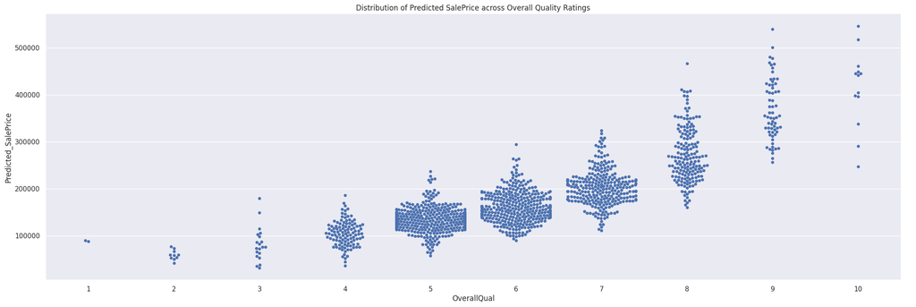

```python
sns.set(rc={'figure.figsize':(10,5)})
sns.catplot(x=test_with_preds["OverallQual"], y=test_with_preds["Predicted_SalePrice"], kind="swarm"
, height=7, aspect=3).set(title="Distribution of Predicted SalePrice across Overall Quality Ratings")
plt.show();
```

The overall pattern is consistent with the training set: higher OverallQual corresponds to higher predicted sale prices.

**Actual vs Predicted SalePrice**

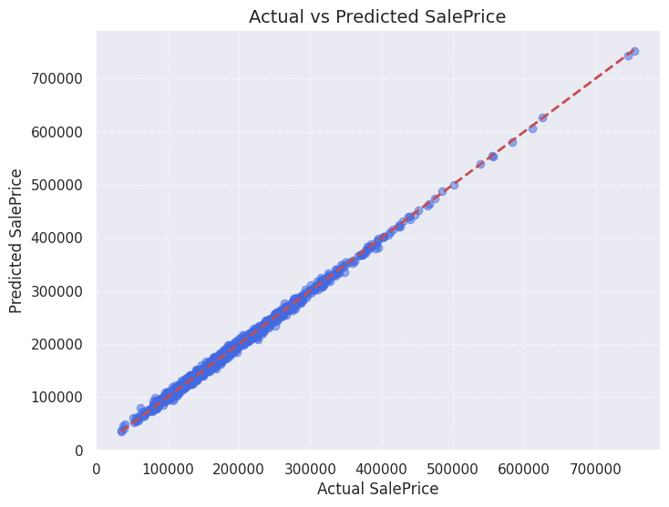

```python
# Predict on validation (or training) set
y_pred_train = best_model.predict(X)

# Scatter plot of Actual vs Predicted SalePrice
plt.figure(figsize=(8,6))
plt.scatter(y, y_pred_train, alpha=0.5, color="royalblue")

# Add diagonal line (perfect predictions)
plt.plot([y.min(), y.max()], [y.min(), y.max()], 'r--', lw=2)

plt.xlabel("Actual SalePrice", fontsize=12)
plt.ylabel("Predicted SalePrice", fontsize=12)
plt.title("Actual vs Predicted SalePrice", fontsize=14)
plt.grid(True, linestyle="--", alpha=0.6)
plt.show();
```

## Conclusion

For Kaggle Submission

```python
# Fit best model on full training data
best_model = xgb_pipeline.fit(X, y)

# Predict on test_clean
y_pred_test = best_model.predict(test_clean)

# Create DataFrame with only Id and prediction
submission_df = pd.DataFrame({
    "Id": test["Id"],
    "Predicted_SalePrice": y_pred_test
})

submission_df.to_csv("submission.csv", index=False)
print("Submission file created successfully!")
# Show top 5 rows
print("\nTop five predictions:")
print(submission_df.head())
```

```
Submission file created successfully!

Top five predictions:
     Id  Predicted_SalePrice
0  1461        123946.570312
1  1462        156981.468750
2  1463        177560.109375
3  1464        191968.656250
4  1465        190450.125000
```

```python
# Download the file to your local computer
from google.colab import files
files.download("submission.csv")
```